# Evaluating posterior sensitivity

Next we look at sensitivity of the predictions, not sensitivity of the parameters. This requires to focus our predictions at specific points. Let’s take the 6-point summary of the observed range of $x$.

```r
# this requires a work-around to get the predictions in the draws object
# code below is ugly but works, need to fix it later

draws_fit3 <- as_draws_df(fit3)

predx <- function(draws, x) {
  tilde_mu <- draws$tilde_v * (draws$inv_var_x * draws$mu_x +
                                 draws$inv_var_mex * x)
  draws$b_Intercept + draws$b_x_obs * tilde_mu
}

preds <- with(draws_fit3, {
  data.frame(
    pred_minX    = predx(draws_fit3, min(data_list$x_obs)),
    pred_Q1X     = predx(draws_fit3, quantile(data_list$x_obs, .25)),
    pred_medianX = predx(draws_fit3, median(data_list$x_obs)),
    pred_meanX   = predx(draws_fit3, mean(data_list$x_obs)),
    pred_Q3X     = predx(draws_fit3, quantile(data_list$x_obs, .75)),
    pred_maxX    = predx(draws_fit3, max(data_list$x_obs))
  )
})
preds$.chain <- draws_fit3$.chain
preds$.iteration <- draws_fit3$.iteration
preds$.draw <- draws_fit3$.draw

draws_fit3 <- bind_draws(draws_fit3, as_draws_df(preds))

# then we can use priorsense again
powerscale_sensitivity(
  draws_fit3,
  variable = c("pred_minX","pred_Q1X","pred_medianX",
               "pred_meanX","pred_Q3X","pred_maxX")
)
```

```
Sensitivity based on cjs_dist
Prior selection: all priors
Likelihood selection: all data

     variable prior likelihood diagnosis
    pred_minX 0.015      0.102         -
     pred_Q1X 0.011      0.099         -
 pred_medianX 0.016      0.100         -
   pred_meanX 0.017      0.101         -
     pred_Q3X 0.018      0.103         -
    pred_maxX 0.019      0.100         -
```

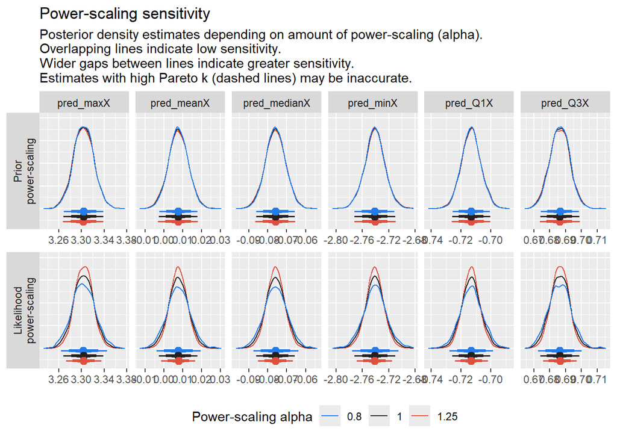

```r
powerscale_plot_dens(
  draws_fit3,
  variable = c("pred_minX","pred_Q1X","pred_medianX",
               "pred_meanX","pred_Q3X","pred_maxX")
)
```

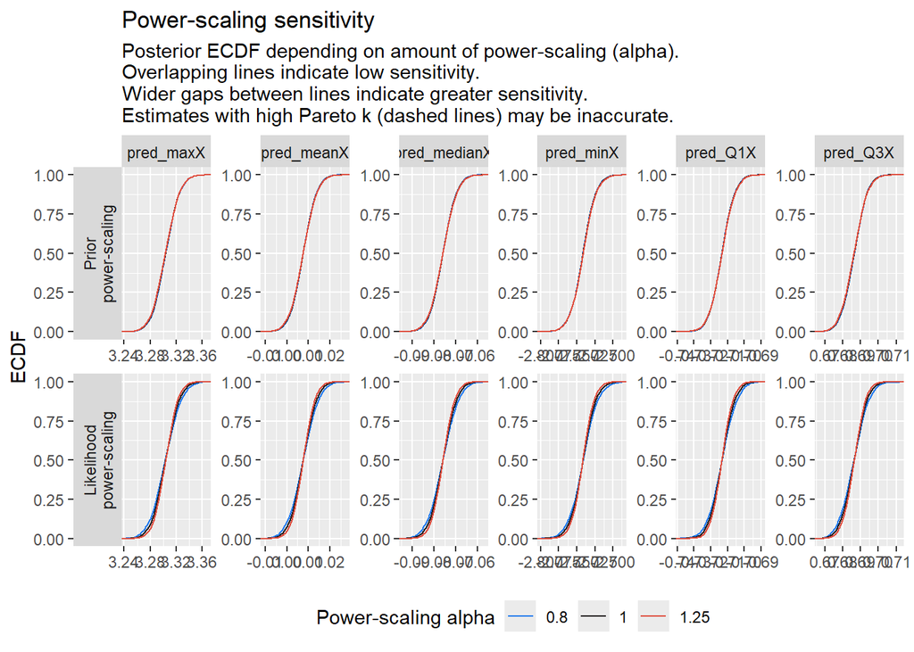

```r
powerscale_plot_ecdf(
  draws_fit3,
  variable = c("pred_minX","pred_Q1X","pred_medianX",
               "pred_meanX","pred_Q3X","pred_maxX")
)
```

**Warning**

But beware: *Like most diagnostics, when power-scaling sensitivity analysis does not indicate sensitivity, this only means that it could not detect sensitivity to power-scaling, not that the model is certainly well-behaved or insensitive to other types of perturbations.*

Kallioinen N., Paananen T., Bürkner P.-C. & Vehtari A. (2023). Detecting and diagnosing prior and likelihood sensitivity with power-scaling. Statistics and Computing 34 (1): 57. https://doi.org/10.1007/s11222-023-10366-5.